# Data 608 - Final Project

Leticia Salazar

December 11, 2022

$~$

# Polycystic Ovarian Syndrome (PCOS)

$~$

## Overview:

Polycystic ovarian syndrome (PCOS) is a reproductive hormonal imbalance condition affecting as much as 5 million women in the US alone. It’s believed that genetics and environmental factors can cause PCOS that affect their body physically and emotionally along with their metabolism, overall health and appearance in women. PCOS causes problems in ovaries making it hard for women to have a healthy menstrual cycle leading to the development of cysts and infertility. Although very common in women of reproductive age, PCOS may begin shortly after puberty but can also develop during the later teenage years and early adulthood.

$~$

Hormones that are involved in PCOS are:

- **Androgens:** aka “male hormones” are present in women with PCOS at higher levels than usual. Excess in androgens can cause symptoms such as acne, unwanted hair, thinning hair, and irregular periods.
- **Insulin:** allows the body to absorb glucose (blood sugar) into the cells for energy. In PCOS, the body doesn’t respond to insulin as intended therefore, elevations in blood glucose levels can be assessed. Such elevations then lead to increased production of androgen.
- **Progesterone:** vital hormone for menstruation and pregnancy; lack of progesterone contributes to irregular periods.

$~$

PCOS Symptoms:

Many of these symptoms can be attributed to other causes or go unnoticed but it is very common for PCOS to go undiagnosed for some time. Here are some symptoms that help with the diagnosis:

- **Irregular periods:** irregular or missed periods as are a result of not ovulating is a common signs of PCOS
- **Polycystic ovaries:** some may develop cysts in their ovaries but some don’t. Ovaries may be enlarged and follicles surrounding their eggs therefore failing to function regularly.
- **Excess androgen:** elevated levels of male hormones can cause excess hair and acne.

$~$

Other symptoms may include:

- **Weight gain:** many people with PCOS will have weight gain or obesity that is difficult to manage.
- **Fatigue:** increase in fatigue or low energy is also common
- **Unwanted hair growth:** due to excess androgen, areas such as face, arms, back, chest, hand, toes and abdomen may have excess hair growth.
- **Thinning hair on the head:** hair loss may increase in middle age for those with PCOS
- **Infertility:** PCOS is a leading cause for infertility but not everyone is the same.
- **Acne:** due to hormonal changes, acne can be arise and make skin oilier than usual and cause breakout in the face, chest and upper back.
- **Darkening of skin:** areas such as under arms, breasts or back of your neck may get dark, patchy or thicken
- **Mood changes:** mood swings, depression and anxiety can increase
- **Pelvic pain:** pain may occur with periods along with heavy bleeding or without bleeding
- **Headaches:** can occur due to hormonal changes
- **Sleep problems:** most people often suffer with problem such as insomnia or poor sleep. These arise due to many factors but a common one is having sleep apnea (sleep disorder). Even when you fall asleep you wake up as if you have not slept at all or have trouble falling asleep.
- **Depression:** can arise due to symptoms that can alter your appearance and have a negative impact on your emotions.

**It’s good to note that not everyone who is diagnosed with PCOS experiences all of these symptoms and should always consult with a their PCP or OBGYN to get an accurate diagnosis.**

$~$

### Load Libraries:

These are the libraries used to explore, prepare and visualize the data

```r
library(tidyverse)
library(dplyr)
library(DataExplorer)
library(hrbrthemes)
library(ggplot2)
library(gridExtra)
library(shiny)
library(plotly)
library(shinythemes)
```

$~$

### Load data:

Below is a short description of the variables of interest in the data sets:

- The data sets I will be using are from [Kaggle](https://www.kaggle.com/datasets/prasoonkottarathil/polycystic-ovary-syndrome-pcos) collected from 10 different hospital across Kerala, India.

Things to consider and understand the data set:

- Units used are feet to cm
- For Yes | No questions
  - Yes = 1
  - No = 0
- Blood Groups:
  - A+ = 11
  - A- = 12
  - B+ = 13
  - B- = 14
  - O+ = 15
  - O- = 16
  - AB+ = 17
  - AB- = 18
- RBS means Random glucose test
- PRG means PCOS related genes
- Blood pressure entered as systolic and diastolic separately
- Beta-HCG cases are mentioned as Case I and II: these are pregnancy hormones
  - The detection of beta hCG (Case I) shows more accuracy in pregnancy test than the hCG (Case II) detection test.
- AMH(ng/mL) detects ovarian reserve (egg count)
- RR(breathes/min) is respiration rates
- Hb(g/dl) is hemoglobin levels that measures how much hemoglobin is in your blood.
- FSH is follicle stimulating hormone
  - FSH helps control the menstrual cycle and stimulates the growth of eggs in the ovaries. FSH levels in women change throughout the menstrual cycle, with the highest levels happening just before an egg is released by the ovary.
- LH is luteinizing hormone (increases during ovulation)
  - Before menopause - 5 to 25 IU/L
  - Level peaks even higher around the middle of the menstrual cycle
  - Level then becomes higher after menopause - 14.2 to 52.3 IU/L
- TSH is thyroid stimulating hormone
  - levels too high or low may be a sign of thyroid problem
- PRL is prolactin in blood
  - causes the breasts to grow and make milk during pregnancy and after birth. Prolactin levels are normally high for pregnant women and new mothers. Levels are normally low for nonpregnant women and for men.
- Cycle(R/I) values are as follows:
  - 4 indicates irregular menstrual cycle
  - 2 indicates a regular menstrual cycle

$~$

I have included the original data sets in my [GitHub](https://github.com/letisalba/Data_608/tree/master/Final%20Project/csv) account and read from this location.

Lets view the `pcos` data:

|  | Sl..No | Patient.File.No. | PCOS..Y.N. | I...beta.HCG.mIU.mL. | II....beta.HCG.mIU.mL. | AMH.ng.mL. |
| --- | --- | --- | --- | --- | --- | --- |
| 1 | 1 | 10001 | 0 | 1.99 | 1.99 | 2.07 |
| 2 | 2 | 10002 | 0 | 60.80 | 1.99 | 1.53 |
| 3 | 3 | 10003 | 1 | 494.08 | 494.08 | 6.63 |
| 4 | 4 | 10004 | 0 | 1.99 | 1.99 | 1.22 |

… And the `pcos_infertility` data:

|  | Sl..No | Patient.File.No. | PCOS..Y.N. | Age..yrs. | Weight..Kg. | Height.Cm. | BMI | Blood.Group | Pulse.rate.bpm. | RR..breaths.min. | Hb.g.dl. | Cycle.R.I. | Cycle.length.days. | Marraige.Status..Yrs. | Pregnant.Y.N. | No..of.aborptions | I...beta.HCG.mIU.mL. | II....beta.HCG.mIU.mL. | FSH.mIU.mL. | LH.mIU.mL. | FSH.LH | Hip.inch. | Waist.inch. | Waist.Hip.Ratio | TSH..mIU.L. | AMH.ng.mL. | PRL.ng.mL. | Vit.D3..ng.mL. | PRG.ng.mL. | … |
| --- | --- | --- | --- | --- | --- | --- | --- | --- | --- | --- | --- | --- | --- | --- | --- | --- | --- | --- | --- | --- | --- | --- | --- | --- | --- | --- | --- | --- | --- | --- |
| 1 | 1 | 1 | 0 | 28 | 44.6 | 152.0 | 19.3 | 15 | 78 | 22 | 10.48 | 2 | 5 | 7 | 0 | 0 | 1.99 | 1.99 | 7.95 | 3.68 | #NAME? | 36 | 30 | #NAME? | 0.68 | 2.07 | 45.16 | 17.1 | 0.57 | … |
| 2 | 2 | 2 | 0 | 36 | 65.0 | 161.5 | #NAME? | 15 | 74 | 20 | 11.70 | 2 | 5 | 11 | 1 | 0 | 60.80 | 1.99 | 6.73 | 1.09 | #NAME? | 38 | 32 | #NAME? | 3.16 | 1.53 | 20.09 | 61.3 | 0.97 | … |
| 3 | 3 | 3 | 1 | 33 | 68.8 | 165.0 | #NAME? | 11 | 72 | 18 | 11.80 | 2 | 5 | 10 | 1 | 0 | 494.08 | 494.08 | 5.54 | 0.88 | #NAME? | 40 | 36 | #NAME? | 2.54 | 6.63 | 10.52 | 49.7 | 0.36 | … |
| 4 | 4 | 4 | 0 | 37 | 65.0 | 148.0 | #NAME? | 13 | 72 | 20 | 12.00 | 2 | 5 | 4 | 0 | 0 | 1.99 | 1.99 | 8.06 | 2.36 | #NAME? | 42 | 36 | #NAME? | 16.41 | 1.22 | 36.90 | 33.4 | 0.36 | … |

$~$

### Data Exploration:

The first data set `pcos` includes 541 observations and a total of 6 variables. The second data set `pcos_infertility` includes 541 observations and a total of 45 variables. Notice that the column names are not clear enough for readers, this will be tackled in the data preparation section.

$~$

The `pcos` data:

```
Rows: 541
Columns: 6
$ Sl..No                 <int> 1, 2, 3, 4, 5, 6, 7, 8, 9, 10, 11, 12, 13, 14, 15, 16, 17, 18, 19, 20, 21, 22, 23, 24, 25, 26, 27, 28, 29, 30, 31, 32, 33, 34, 35, 36, 37, 38, 39, 40, 41, 42, 43, 44, 45, 46, 47, 48, 49, 50, 51, 52, …
$ Patient.File.No.       <int> 10001, 10002, 10003, 10004, 10005, 10006, 10007, 10008, 10009, 10010, 10011, 10012, 10013, 10014, 10015, 10016, 10017, 10018, 10019, 10020, 10021, 10022, 10023, 10024, 10025, 10026, 10027, 10028, 100…
$ PCOS..Y.N.             <int> 0, 0, 1, 0, 0, 0, 0, 0, 0, 0, 0, 0, 1, 0, 0, 0, 0, 0, 0, 1, 0, 0, 0, 0, 1, 0, 1, 0, 0, 1, 0, 1, 0, 0, 0, 0, 0, 0, 0, 0, 0, 0, 0, 0, 1, 0, 1, 0, 0, 1, 1, 0, 1, 0, 0, 0, 0, 0, 0, 0, 0, 1, 0, 0, 0, 0, 0…
$ I...beta.HCG.mIU.mL.   <dbl> 1.990, 60.800, 494.080, 1.990, 801.450, 237.970, 1.990, 100.510, 1.990, 1.990, 158.510, 1.990, 1214.230, 1.990, 1.990, 1.990, 8104.210, 1.990, 1.990, 23.580, 1.990, 749.980, 218.650, 13.000, 610.630,…
$ II....beta.HCG.mIU.mL. <dbl> 1.99, 1.99, 494.08, 1.99, 801.45, 1.99, 1.99, 100.51, 1.99, 1.99, 158.51, 1.99, 1214.23, 1.99, 1.99, 1.99, 91.55, 1.99, 1.99, 1.99, 1.99, 749.98, 218.65, 13.00, 610.63, 4490.18, 1.99, 11.24, 15.00, 7…
$ AMH.ng.mL.             <chr> "2.07", "1.53", "6.63", "1.22", "2.26", "6.74", "3.05", "1.54", "1", "1.61", "4.47", "1.67", "7.94", "2.38", "0.88", "0.69", "3.78", "1.92", "1", "2.07", "2.85", "2.13", "4.13", "2.5", "1.89", "0.26"…
```

$~$

The `pcos_infertility` data:

```
Rows: 541
Columns: 45
$ Sl..No                 <int> 1, 2, 3, 4, 5, 6, 7, 8, 9, 10, 11, 12, 13, 14, 15, 16, 17, 18, 19, 20, 21, 22, 23, 24, 25, 26, 27, 28, 29, 30, 31, 32, 33, 34, 35, 36, 37, 38, 39, 40, 41, 42, 43, 44, 45, 46, 47, 48, 49, 50, 51, 52, …
$ Patient.File.No.       <int> 1, 2, 3, 4, 5, 6, 7, 8, 9, 10, 11, 12, 13, 14, 15, 16, 17, 18, 19, 20, 21, 22, 23, 24, 25, 26, 27, 28, 29, 30, 31, 32, 33, 34, 35, 36, 37, 38, 39, 40, 41, 42, 43, 44, 45, 46, 47, 48, 49, 50, 51, 52, …
$ PCOS..Y.N.             <int> 0, 0, 1, 0, 0, 0, 0, 0, 0, 0, 0, 0, 1, 0, 0, 0, 0, 0, 0, 1, 0, 0, 0, 0, 1, 0, 1, 0, 0, 1, 0, 1, 0, 0, 0, 0, 0, 0, 0, 0, 0, 0, 0, 0, 1, 0, 1, 0, 0, 1, 1, 0, 1, 0, 0, 0, 0, 0, 0, 0, 0, 1, 0, 0, 0, 0, 0…
$ Age..yrs.              <int> 28, 36, 33, 37, 25, 36, 34, 33, 32, 36, 20, 26, 25, 38, 34, 38, 29, 36, 31, 30, 25, 38, 34, 28, 34, 41, 30, 20, 25, 28, 32, 34, 31, 38, 28, 32, 37, 26, 36, 20, 32, 29, 28, 24, 29, 25, 28, 26, 34, 27,…
$ Weight..Kg.            <dbl> 44.6, 65.0, 68.8, 65.0, 52.0, 74.1, 64.0, 58.5, 40.0, 52.0, 71.0, 49.0, 74.0, 50.0, 57.3, 80.5, 43.0, 69.2, 52.4, 85.0, 64.0, 50.0, 64.2, 65.0, 63.0, 42.0, 76.0, 68.0, 62.0, 56.0, 50.0, 57.0, 58.0, 5…
$ Height.Cm.             <dbl> 152.0, 161.5, 165.0, 148.0, 161.0, 165.0, 156.0, 159.0, 158.0, 150.0, 163.0, 160.0, 152.0, 152.0, 162.0, 154.0, 148.0, 160.0, 159.0, 165.0, 156.0, 156.0, 155.0, 152.0, 158.0, 152.0, 160.0, 152.0, 158…
$ BMI                    <chr> "19.3", "#NAME?", "#NAME?", "#NAME?", "#NAME?", "#NAME?", "#NAME?", "#NAME?", "#NAME?", "#NAME?", "#NAME?", "#NAME?", "#NAME?", "#NAME?", "#NAME?", "#NAME?", "#NAME?", "#NAME?", "#NAME?", "#NAME?", "…
$ Blood.Group            <int> 15, 15, 11, 13, 11, 15, 11, 13, 11, 15, 15, 13, 17, 13, 13, 13, 13, 13, 17, 16, 11, 15, 15, 13, 11, 12, 15, 17, 15, 13, 17, 11, 15, 15, 15, 11, 15, 11, 13, 13, 15, 13, 13, 15, 17, 15, 15, 13, 11, 15,…
$ Pulse.rate.bpm.        <int> 78, 74, 72, 72, 72, 78, 72, 72, 72, 80, 80, 72, 72, 74, 74, 78, 80, 72, 72, 72, 70, 72, 74, 74, 72, 80, 75, 72, 78, 78, 78, 72, 72, 72, 76, 72, 74, 70, 78, 74, 78, 72, 78, 72, 78, 70, 72, 74, 78, 72,…
$ RR..breaths.min.       <int> 22, 20, 18, 20, 18, 28, 18, 20, 18, 20, 20, 20, 18, 20, 22, 22, 20, 18, 18, 18, 18, 18, 20, 22, 20, 20, 18, 20, 22, 22, 22, 22, 18, 18, 20, 22, 18, 18, 22, 16, 22, 16, 18, 16, 22, 18, 18, 18, 24, 18,…
$ Hb.g.dl.               <dbl> 10.48, 11.70, 11.80, 12.00, 10.00, 11.20, 10.90, 11.00, 11.80, 10.00, 10.00, 9.50, 11.70, 12.10, 11.70, 11.40, 11.10, 10.80, 12.70, 12.50, 11.20, 11.00, 12.10, 10.50, 11.20, 11.50, 11.20, 10.00, 11.6…
$ Cycle.R.I.             <int> 2, 2, 2, 2, 2, 2, 2, 2, 2, 4, 2, 2, 4, 2, 2, 2, 2, 2, 2, 4, 2, 4, 2, 2, 2, 2, 4, 4, 2, 4, 2, 2, 2, 2, 2, 2, 4, 2, 2, 4, 2, 2, 4, 2, 4, 2, 2, 2, 2, 4, 4, 2, 2, 2, 2, 2, 2, 2, 2, 4, 2, 2, 2, 4, 4, 2, 2…
$ Cycle.length.days.     <int> 5, 5, 5, 5, 5, 5, 5, 5, 5, 2, 5, 5, 2, 5, 5, 5, 5, 5, 5, 7, 6, 9, 5, 5, 5, 5, 3, 3, 5, 3, 4, 4, 5, 5, 5, 5, 7, 5, 5, 0, 5, 5, 9, 5, 7, 5, 5, 5, 5, 3, 10, 5, 4, 5, 5, 5, 5, 5, 5, 9, 5, 5, 5, 2, 8, 5, …
```

[output cut: 32 more lines]

$~$

Let’s look at the distribution of our data sets using histograms:

`pcos` data:

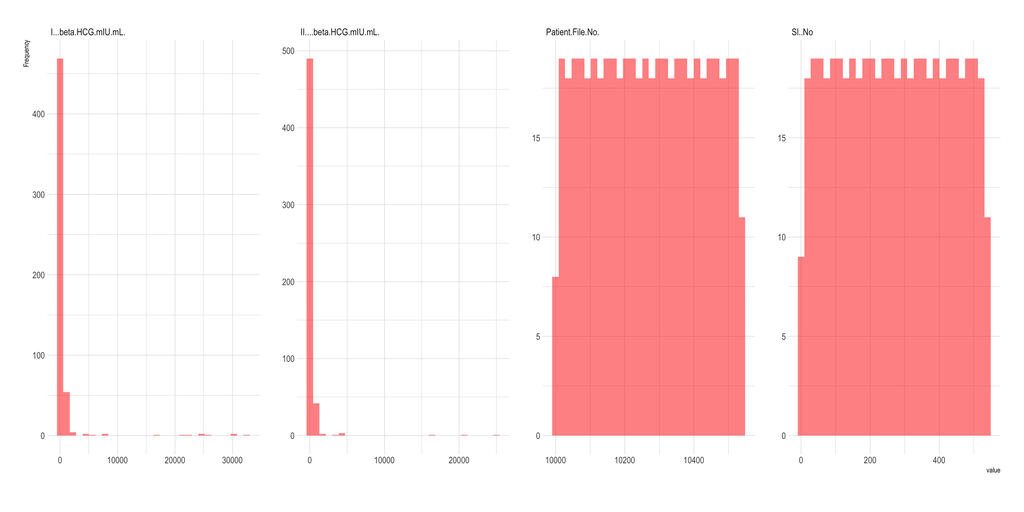

$~$

`pcos_infertility` data:

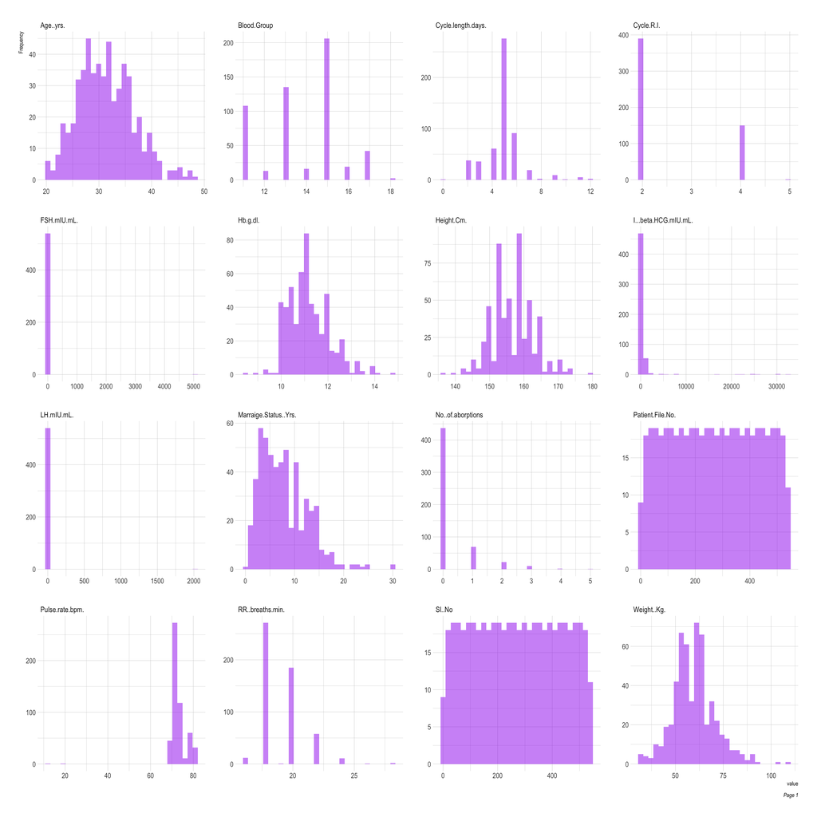

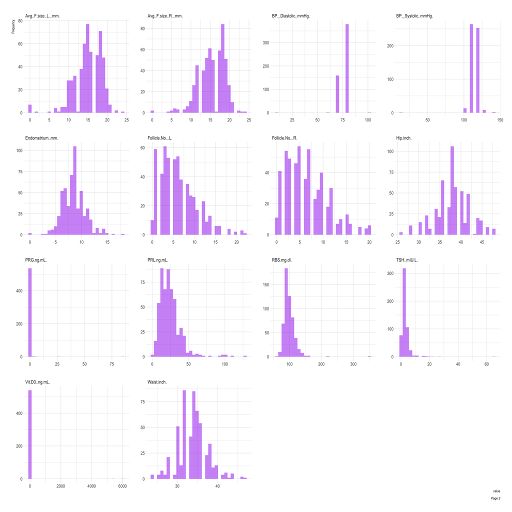

$~$

### Data Preparation:

Before I start the cleaning process I converted the data sets as numeric since the class of some of the variables differ.

$~$

Lets look at the column names of both data sets to be able to start tidying the data:

`pcos`:

```
[1] "Sl..No"                 "Patient.File.No."       "PCOS..Y.N."             "I...beta.HCG.mIU.mL."   "II....beta.HCG.mIU.mL." "AMH.ng.mL."
```

$~$

`pcos_infertility`:

```
 [1] "Sl..No"                 "Patient.File.No."       "PCOS..Y.N."             "Age..yrs."              "Weight..Kg."            "Height.Cm."             "BMI"                    "Blood.Group"            "Pulse.rate.bpm."
[10] "RR..breaths.min."       "Hb.g.dl."               "Cycle.R.I."             "Cycle.length.days."     "Marraige.Status..Yrs."  "Pregnant.Y.N."          "No..of.aborptions"      "I...beta.HCG.mIU.mL."   "II....beta.HCG.mIU.mL."
[19] "FSH.mIU.mL."            "LH.mIU.mL."             "FSH.LH"                 "Hip.inch."              "Waist.inch."            "Waist.Hip.Ratio"        "TSH..mIU.L."            "AMH.ng.mL."             "PRL.ng.mL."
[28] "Vit.D3..ng.mL."         "PRG.ng.mL."             "RBS.mg.dl."             "Weight.gain.Y.N."       "hair.growth.Y.N."       "Skin.darkening..Y.N."   "Hair.loss.Y.N."         "Pimples.Y.N."           "Fast.food..Y.N."
[37] "Reg.Exercise.Y.N."      "BP._Systolic..mmHg."    "BP._Diastolic..mmHg."   "Follicle.No...L."       "Follicle.No...R."       "Avg..F.size..L...mm."   "Avg..F.size..R...mm."   "Endometrium..mm."       "X"
```

$~$

As mentioned earlier, my data preparation will mainly consist of renaming columns, targeting missing values whether it is by replacing them with a mean, median or mode for `Marriage Status (Yrs)` and `Fast Food (Y/N)` or calculating the values as a whole as its the case of `BMI`, `FSH.LH` and `Waist.Hip.Ratio`. I’ll also be converting certain columns to metric, remove columns that are duplicate or not need so that it’s easier to manage when I merge my two data sets.

$~$

Here’s the results after part 1 of the preparation process:

|  | Sl.No | PCOS | Ibeta-HCG(mIU/mL) | IIbeta-HCG(mIU/mL) | AMH(ng/mL) | Age(yrs) | Weight(kg) | Height(cm) | BMI | Blood_Group | Pulse rate(bpm) | RR(breaths/min) | Hb(g/dl) | Cycle(R/I) | Cycle_length(days) | Marriage_Status(yrs) | Pregnant | No_of_abortions | FSH(mIU/mL) | LH(mIU/mL) | FSH-LH | Hip(in) | Waist(in) | Waist-Hip_Ratio | TSH (mIU/L) | PRL(ng/mL) | Vit_D3(ng/mL) | PRG(ng/mL) | RBS(mg/dl) | … |
| --- | --- | --- | --- | --- | --- | --- | --- | --- | --- | --- | --- | --- | --- | --- | --- | --- | --- | --- | --- | --- | --- | --- | --- | --- | --- | --- | --- | --- | --- | --- |
| 1 | 1 | 0 | 1.99 | 1.99 | 2.07 | 28 | 44.6 | 152.0 | 19.3 | 15 | 78 | 22 | 10.48 | 2 | 5 | 7 | 0 | 0 | 7.95 | 3.68 | NA | 36 | 30 | NA | 0.68 | 45.16 | 17.1 | 0.57 | 92 | … |
| 2 | 2 | 0 | 60.80 | 1.99 | 1.53 | 36 | 65.0 | 161.5 | NA | 15 | 74 | 20 | 11.70 | 2 | 5 | 11 | 1 | 0 | 6.73 | 1.09 | NA | 38 | 32 | NA | 3.16 | 20.09 | 61.3 | 0.97 | 92 | … |
| 3 | 3 | 1 | 494.08 | 494.08 | 6.63 | 33 | 68.8 | 165.0 | NA | 11 | 72 | 18 | 11.80 | 2 | 5 | 10 | 1 | 0 | 5.54 | 0.88 | NA | 40 | 36 | NA | 2.54 | 10.52 | 49.7 | 0.36 | 84 | … |
| 4 | 4 | 0 | 1.99 | 1.99 | 1.22 | 37 | 65.0 | 148.0 | NA | 13 | 72 | 20 | 12.00 | 2 | 5 | 4 | 0 | 0 | 8.06 | 2.36 | NA | 42 | 36 | NA | 16.41 | 36.90 | 33.4 | 0.36 | 76 | … |
| 5 | 5 | 0 | 801.45 | 801.45 | 2.26 | 25 | 52.0 | 161.0 | NA | 11 | 72 | 18 | 10.00 | 2 | 5 | 1 | 1 | 0 | 3.98 | 0.90 | NA | 37 | 30 | NA | 3.57 | 30.09 | 43.8 | 0.38 | 84 | … |
| 6 | 6 | 0 | 237.97 | 1.99 | 6.74 | 36 | 74.1 | 165.0 | NA | 15 | 78 | 28 | 11.20 | 2 | 5 | 8 | 1 | 0 | 3.24 | 1.07 | NA | 44 | 38 | NA | 1.60 | 16.18 | 52.4 | 0.30 | 76 | … |

$~$

Checking for missing data:

```
               Sl.No                 PCOS    Ibeta-HCG(mIU/mL)   IIbeta-HCG(mIU/mL)           AMH(ng/mL)             Age(yrs)           Weight(kg)           Height(cm)                  BMI          Blood_Group      Pulse rate(bpm)
                   0                    0                    0                    0                    1                    0                    0                    0                  299                    0                    0
     RR(breaths/min)             Hb(g/dl)           Cycle(R/I)   Cycle_length(days) Marriage_Status(yrs)             Pregnant      No_of_abortions          FSH(mIU/mL)           LH(mIU/mL)               FSH-LH              Hip(in)
                   0                    0                    0                    0                    1                    0                    0                    0                    0                  532                    0
           Waist(in)      Waist-Hip_Ratio          TSH (mIU/L)           PRL(ng/mL)        Vit_D3(ng/mL)           PRG(ng/mL)           RBS(mg/dl)          Weight_gain          hair_growth       Skin_darkening            Hair_loss
                   0                  532                    0                    0                    0                    0                    0                    0                    0                    0                    0
             Pimples            Fast_food         Reg_Exercise    BP_Systolic(mmHg)   BP_Diastolic(mmHg)       Follicle_No(L)       Follicle_No(R)    Avg_F_size(L)(mm)    Avg_F_size(R)(mm)      Endometrium(mm)
                   0                    1                    0                    0                    0                    0                    0                    0                    0                    0
```

$~$

For part 2, I tackled the missing values by first transforming `Height` from cm to m, calculate `BMI`, `Waist-hip ratio` and `FSH/LH`. Then after careful consideration to the data, I decided to use the median number to replace the missing values in `Marriage_Status(yrs)`, `AMH(ng/mL)` and `Fast_food` since it didn’t disrupt the data’s distribution.

$~$

After tidying up the data, below is the final distribution:

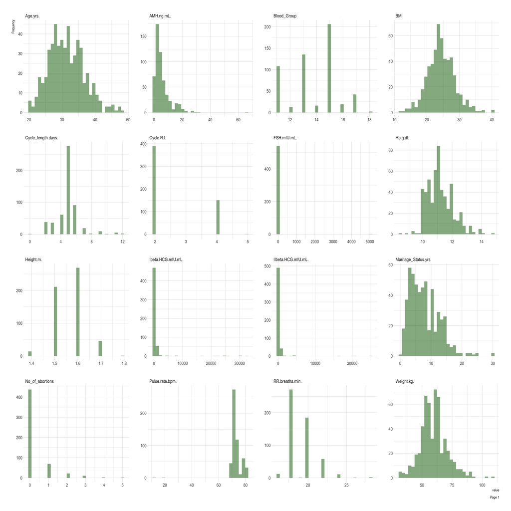

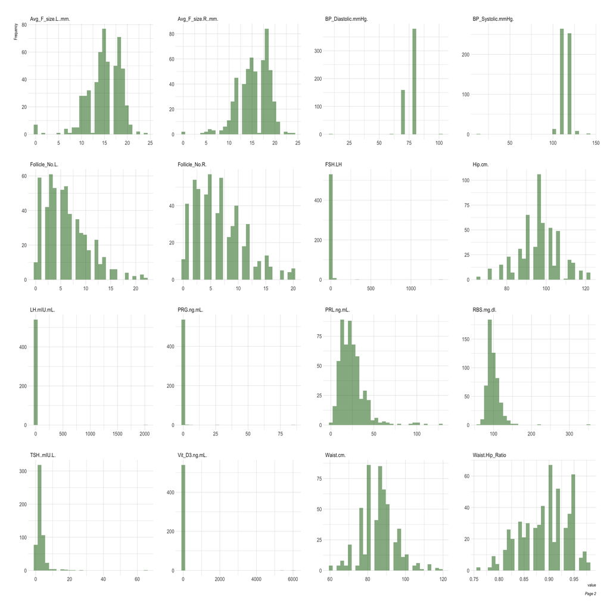

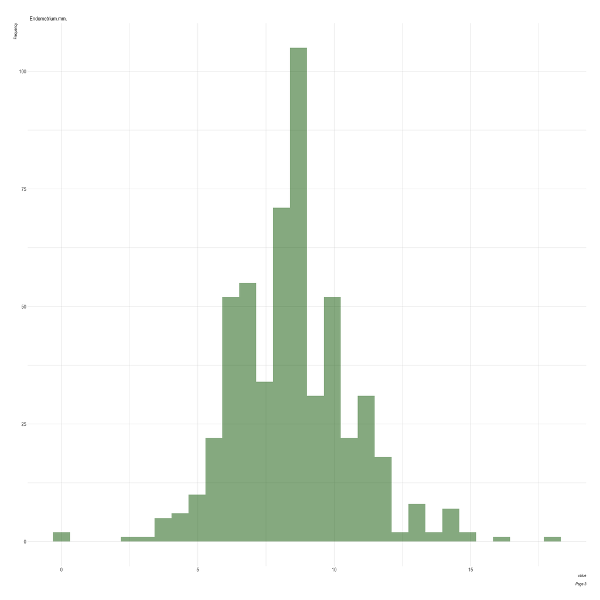

$~$

### Plots:

Now that the data is ready, I have created some plots to better understand the relationship of each variable.

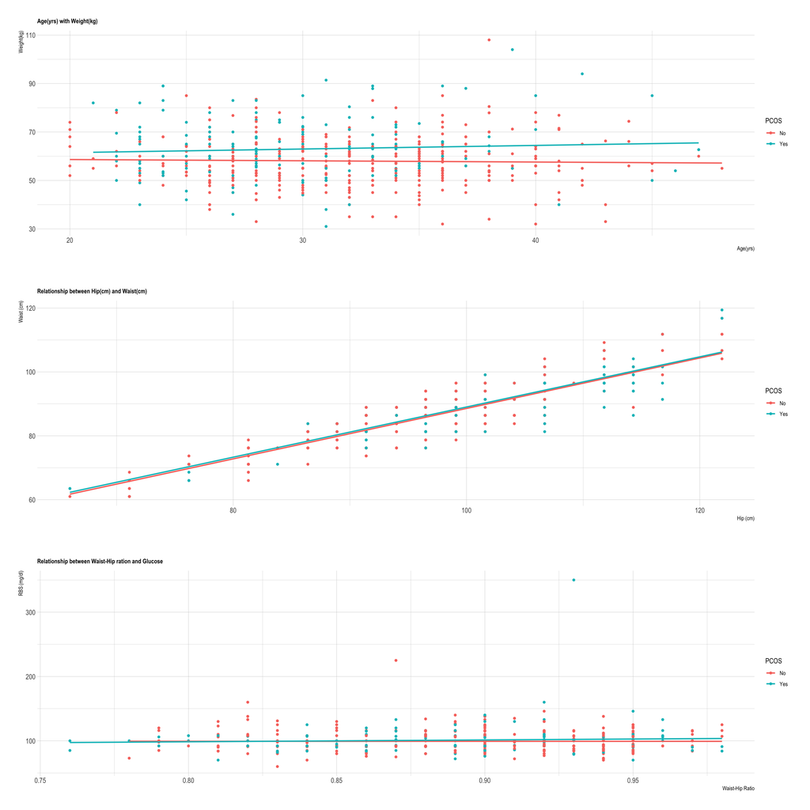

$~$

Below I have statistics based on yes / no variables we were given. Out of 541 women:

- 32.72% reported to have PCOS
- 38.08% of women reported to being pregnant
- 37.71% reported to experience weight gain
- 27.36% reported to experience hair growth
- 30.68% experience skin darkening
- 45.29% reported to experience hair loss
- 48.98% reported to experience pimples
- 51.57% reported to have fast food
- 24.77% reported to exercise regularly

$~$

$~$

$~$

$~$

$~$

### Conclusion:

Being diagnosed almost 2 years ago with PCOS I was intrigued to learn more and explore the data that was available. Although not much data was easily accessible this is a start to explore differences or similarities women share with their physical aspect and blood work. It’s also important to be aware of symptoms experienced by PCOS because it’s such symptoms that can always be misinterpreted as “too much stress” or “lose weight” by doctors. Essentially we could use these commonalities to help women all over learn to distinguish symptoms not only by the physical aspects of PCOS but also during a routine lab work. After advocating for myself with multiple doctors over the span of 6 years I saw the true value in listening to your body and sharing my experience with others. I hope this project is able to make women aware of what to look out for, what kind of questions to ask, and to be persistent with their health because who knows our bodies better than ourselves.

$~$

```r
# # Filtering data
# #pcosdata <- filter(pcos_data)
#
# #Shiny app prep
# # Define UI for app
# ui <- fluidPage(
#   # App title ----
#   titlePanel("Polycystic Ovarian Syndrome"),
#   # Sidebar layout with input and output definitions ----
#   sidebarLayout(
#     # Sidebar panel for inputs ----
#     sidebarPanel(
#       img(src = "pcos.jpg", height = 200, width = 200)
#       ),
#     mainPanel(
#       # Output: Tabset w/ plot
#       tabsetPanel(type = "tabs",
#                   tabPanel("Overview", plotOutput("Overview")),
#       h3("Overview:"),
#       p("Polycystic ovarian syndrome (PCOS) is a reproductive hormonal imbalance condition affecting as much as 5 million women in the US alone. It's believed that genetics and environmental factors can cause PCOS that affect their body physically and emotionally along with their metabolism, overall health and appearance in women. PCOS causes problems in ovaries making it hard for women to have a healthy menstrual cycle leading to the development of cysts and infertility. Although very common in women of reproductive age, PCOS may begin shortly after puberty but can also develop during the later teenage years and early adulthood.", style = "font-family: 'times'; font-si20pt"),
#       br(),
#       h4("Hormones that are involved in PCOS are:"),
#       p("- Androgens: aka male hormones are present in women with PCOS at higher levels than usual. Excess in androgens can cause symptoms such as acne, unwanted hair, thinning hair, and irregular periods.", style = "font-family: 'times'; font-si20pt"),
#       p("- Insulin: allows the body to absorb glucose (blood sugar) into the cells for energy. In PCOS, the body doesn't respond to insulin as intended therefore, elevations in blood glucose levels can be assessed. Such elevations then lead to increased production of androgen.", style = "font-family: 'times'; font-si20pt"),
#       p("- Progesterone: vital hormone for menstruation and pregnancy; lack of progesterone contributes to irregular periods.", style = "font-family: 'times'; font-si20pt"),
#       br(),
#       h4("PCOS Symptoms:"),
#       p("Many of these symptoms can be attributed to other causes or go unnoticed but it is very common for PCOS to go undiagnosed for some time. Here are some symptoms that help with the diagnosis:", style = "font-family: 'times'; font-si20pt"),
#       p("- Irregular periods: irregular or missed periods as are a result of not ovulating is a common signs of PCOS", style = "font-family: 'times'; font-si20pt"),
#       p("- Polycystic ovaries: some may develop cysts in their ovaries but some don't. Ovaries may be enlarged and follicles surrounding their eggs therefore failing to function regularly.", style = "font-family: 'times'; font-si20pt"),
#       p("- Excess androgen: elevated levels of male hormones can cause excess hair and acne.", style = "font-family: 'times'; font-si20pt"),
#       br(),
#       p("Other symptoms may include:", style = "font-family: 'times'; font-si20pt"),
#       p("- Weight gain: many people with PCOS will have weight gain or obesity that is difficult to manage.", style = "font-family: 'times'; font-si20pt"),
#       p("- Fatigue: increase in fatigue or low energy is also common", style = "font-family: 'times'; font-si20pt"),
#       p("- Unwanted hair growth: due to excess androgen, areas such as face, arms, back, chest, hand, toes and abdomen may have excess hair growth.", style = "font-family: 'times'; font-si20pt"),
#       p("- Thinning hair on the head: hair loss may increase in middle age for those with PCOS", style = "font-family: 'times'; font-si20pt"),
#       p("- Infertility: PCOS is a leading cause for infertility but not everyone is the same.", style = "font-family: 'times'; font-si20pt"),
#       p("- Acne: due to hormonal changes, acne can be arise and make skin oilier than usual and cause breakout in the face, chest and upper back.", style = "font-family: 'times'; font-si20pt"),
#       p("- Darkening of skin: areas such as under arms, breasts or back of your neck may get dark, patchy or thicken", style = "font-family: 'times'; font-si20pt"),
#       p("- Mood changes: mood swings, depression and anxiety can increase", style = "font-family: 'times'; font-si20pt"),
#       p("- Pelvic pain: pain may occur with periods along with heavy bleeding or without bleeding", style = "font-family: 'times'; font-si20pt"),
#       p("- Headaches: can occur due to hormonal changes", style = "font-family: 'times'; font-si20pt"),
#       p("- Sleep problems: most people often suffer with problem such as insomnia or poor sleep. These arise due to many factors but a common one is having sleep apnea (sleep disorder). Even when you fall asleep you wake up as if you have not slept at all or have trouble falling asleep.", style = "font-family: 'times'; font-si20pt"),
#       p("- Depression: can arise due to symptoms that can alter your appearance and have a negative impact on your emotions.", style = "font-family: 'times'; font-si20pt"),
#       h5("It's good to note that not everyone who is diagnosed with PCOS experiences all of these symptoms and should always consult with a their PCP or OBGYN to get an accurate diagnosis."),
#       br(),
#       # tabsetPanel(type = "tabs",
#       #             tabPanel("Yes or No Question", plotOutput("fig1")),
#         )
#       )
#     )
#   )
#
#
#
#
# # Define server logic required to draw a bargraph
# server <- function(input, output) {
#   output$distPlot <- renderPlotly({p1})
# }
#
# # Run the application
# shinyApp(ui, server)
```

```r
# ui = fluidPage(
#     theme = shinytheme("spacelab"),
#     mainPanel(
#       tabsetPanel(
#         tabPanel("Overview"),
#         h3("Overview:"),
#       p("Polycystic ovarian syndrome (PCOS) is a reproductive hormonal imbalance condition affecting as much as 5 million women in the US alone. It's believed that genetics and environmental factors can cause PCOS that affect their body physically and emotionally along with their metabolism, overall health and appearance in women. PCOS causes problems in ovaries making it hard for women to have a healthy menstrual cycle leading to the development of cysts and infertility. Although very common in women of reproductive age, PCOS may begin shortly after puberty but can also develop during the later teenage years and early adulthood.", style = "font-family: 'times'; font-si20pt"),
#       br(),
#       h4("Hormones that are involved in PCOS are:"),
#       p("- Androgens: aka male hormones are present in women with PCOS at higher levels than usual. Excess in androgens can cause symptoms such as acne, unwanted hair, thinning hair, and irregular periods.", style = "font-family: 'times'; font-si20pt"),
#       p("- Insulin: allows the body to absorb glucose (blood sugar) into the cells for energy. In PCOS, the body doesn't respond to insulin as intended therefore, elevations in blood glucose levels can be assessed. Such elevations then lead to increased production of androgen.", style = "font-family: 'times'; font-si20pt"),
#       p("- Progesterone: vital hormone for menstruation and pregnancy; lack of progesterone contributes to irregular periods.", style = "font-family: 'times'; font-si20pt"),
#       br(),
#       h4("PCOS Symptoms:"),
#       p("Many of these symptoms can be attributed to other causes or go unnoticed but it is very common for PCOS to go undiagnosed for some time. Here are some symptoms that help with the diagnosis:", style = "font-family: 'times'; font-si20pt"),
#       p("- Irregular periods: irregular or missed periods as are a result of not ovulating is a common signs of PCOS", style = "font-family: 'times'; font-si20pt"),
#       p("- Polycystic ovaries: some may develop cysts in their ovaries but some don't. Ovaries may be enlarged and follicles surrounding their eggs therefore failing to function regularly.", style = "font-family: 'times'; font-si20pt"),
#       p("- Excess androgen: elevated levels of male hormones can cause excess hair and acne.", style = "font-family: 'times'; font-si20pt"),
#       br(),
#       p("Other symptoms may include:", style = "font-family: 'times'; font-si20pt"),
#       p("- Weight gain: many people with PCOS will have weight gain or obesity that is difficult to manage.", style = "font-family: 'times'; font-si20pt"),
#       p("- Fatigue: increase in fatigue or low energy is also common", style = "font-family: 'times'; font-si20pt"),
#       p("- Unwanted hair growth: due to excess androgen, areas such as face, arms, back, chest, hand, toes and abdomen may have excess hair growth.", style = "font-family: 'times'; font-si20pt"),
#       p("- Thinning hair on the head: hair loss may increase in middle age for those with PCOS", style = "font-family: 'times'; font-si20pt"),
#       p("- Infertility: PCOS is a leading cause for infertility but not everyone is the same.", style = "font-family: 'times'; font-si20pt"),
#       p("- Acne: due to hormonal changes, acne can be arise and make skin oilier than usual and cause breakout in the face, chest and upper back.", style = "font-family: 'times'; font-si20pt"),
#       p("- Darkening of skin: areas such as under arms, breasts or back of your neck may get dark, patchy or thicken", style = "font-family: 'times'; font-si20pt"),
#       p("- Mood changes: mood swings, depression and anxiety can increase", style = "font-family: 'times'; font-si20pt"),
#       p("- Pelvic pain: pain may occur with periods along with heavy bleeding or without bleeding", style = "font-family: 'times'; font-si20pt"),
#       p("- Headaches: can occur due to hormonal changes", style = "font-family: 'times'; font-si20pt"),
#       p("- Sleep problems: most people often suffer with problem such as insomnia or poor sleep. These arise due to many factors but a common one is having sleep apnea (sleep disorder). Even when you fall asleep you wake up as if you have not slept at all or have trouble falling asleep.", style = "font-family: 'times'; font-si20pt"),
#       p("- Depression: can arise due to symptoms that can alter your appearance and have a negative impact on your emotions.", style = "font-family: 'times'; font-si20pt"),
#       h5("It's good to note that not everyone who is diagnosed with PCOS experiences all of these symptoms and should always consult with a their PCP or OBGYN to get an accurate diagnosis."),
#       br(),
#         tabPanel("Tab 2",
#                  plotOutput("fig1")),
#         tabPanel("Tab 3"),
#         tabPanel("Tab 4"),
#
#       )
#     )
#   )
#
# server = function(input, output) {
#
# }
#
# # Run the application
# shinyApp(ui, server)
```

```r
# ui <- navbarPage("PCOS",
#   tabPanel("Overview"),
#     h3("Overview:"),
#       p("Polycystic ovarian syndrome (PCOS) is a reproductive hormonal imbalance condition affecting as much as 5 million women in the US alone. It's believed that genetics and environmental factors can cause PCOS that affect their body physically and emotionally along with their metabolism, overall health and appearance in women. PCOS causes problems in ovaries making it hard for women to have a healthy menstrual cycle leading to the development of cysts and infertility. Although very common in women of reproductive age, PCOS may begin shortly after puberty but can also develop during the later teenage years and early adulthood.", style = "font-family: 'times'; font-si20pt"),
#       br(),
#   tabPanel("Yes or No"),
#            mainPanel(fluidRow(
#              column(1,  plotlyOutput("plot1")),
#              column(2, plotlyOutput("plot2"))
#       ),
#   tabPanel("Table")
#
# )
# )
#
# server <- function(input, output) {
#   output$plot1 <- renderPlot({p1})
#
#   output$plot2 <- renderPlot({p2})
#
#
# }
#
# shinyApp(ui = ui, server = server)
```

```r
# shinyApp(
#   ui = fluidPage(
#     tabsetPanel(
#       tabPanel("Map", fluid = TRUE,
#                sidebarLayout(
#                  sidebarPanel(selectInput("Country", "Select Country", choices = "", selected = "")),
#                  mainPanel(
#                    htmlOutput("Attacks")
#                  )
#                )
#       ),
#       tabPanel("plot", fluid = TRUE,
#                sidebarLayout(
#                  sidebarPanel(sliderInput("year", "Year:", min = 1968, max = 2009, value = 2009, sep='')),
#                  mainPanel(fluidRow(
#                    column(7,  plotlyOutput("")),
#                    column(5, plotlyOutput(""))
#                  )
#                  )
#                )
#       )
#     )
#   ),
#   server = function(input, output) {
#
#   }
# )
```

$~$

## References:

- Kottarathil, P. (2020, October 11). Polycystic ovary syndrome (PCOS). Kaggle. Retrieved October 9, 2022, from https://www.kaggle.com/datasets/prasoonkottarathil/polycystic-ovary-syndrome-pcos
- Stewart, M. M., & Foster, S. (2012). PCOS awareness association. PCOS Awareness Association. Retrieved October 9, 2022, from https://www.pcosaa.org/
- Bartlett, E., & Erlich, L. (2015). Feed your fertility: Your guide to cultivating a healthy pregnancy with traditional Chinese medicine, real food, and holistic living. Fair Winds Press.